# Shiny: User Interface & Server

## Where we stopped last time

## What you know now

The tidyverse (and a few base R functions) essentially…

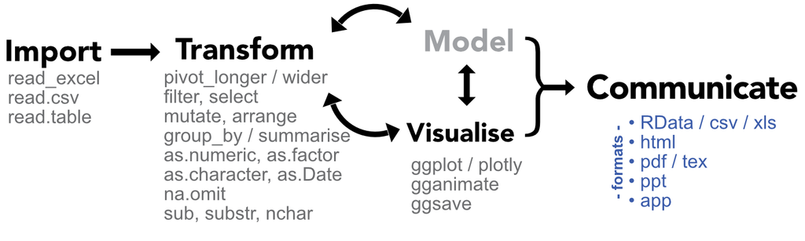

These will be key ingredients in shiny apps!

## About shiny

- Shiny is an amazing package created by HTML/JavaScript blackbelts & heavyweight champions (Winston Chang & Joe Cheng notably)
- It aims at creating dynamic applications directly from RStudio
- It has many extensions and related libraries and formats, such as flexdashboard, **shinythemes**, etc.
- We will proceed in two stages (with each decomposed in several steps):  
  1. build the app in RStudio (99% of the work)  
  2. deploy the app on the web (1% of the work)
- Shiny is very flexible, it is has tons of options. To ease the learning experience, we will work with a simplified framework: **shinydashboard**!

example: https://positiveresidual.com/shiny/nba/

## Resources

- https://shiny.rstudio.com/tutorial/: home of shiny
- https://mastering-shiny.org: THE book (by Hadley Wickham, once again!)
- https://laderast.github.io/gradual_shiny/: great introduction
- https://github.com/grabear/awesome-rshiny: exhaustive list of resources
- https://rstudio.github.io/shinydashboard/get_started.html: simplified shiny!
- https://shiny.rstudio.com/articles/: to go further
- https://shiny.rstudio.com/images/shiny-cheatsheet.pdf: cheat sheet!

Alternatives: **flexdashboard** (if you’re curious)

- https://rmarkdown.rstudio.com/flexdashboard/: introduction
- https://rmarkdown.rstudio.com/flexdashboard/shiny.html: interface with shiny

In Python:

- [https://dash.plotly.com/r](https://dashr.plotly.com): the plotly alternative (DASH)
- https://flask.palletsprojects.com/en/2.0.x/: simples apps in Python
- https://www.streamlit.io: other apps in Python

## Principles

## Schematic view

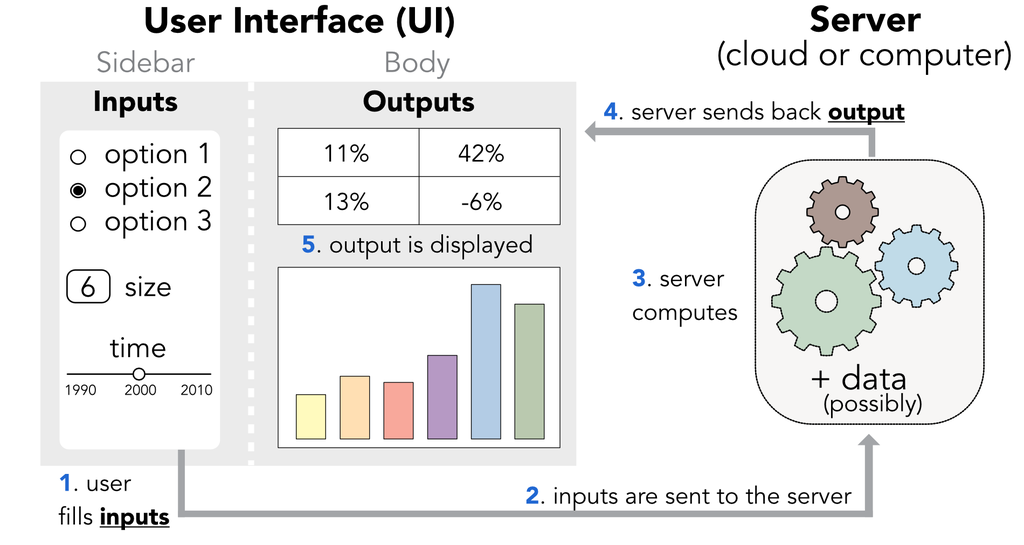

## Output material

Any combination of:

- simple numbers, highlighted figures (aggregate statistics)
- tables (e.g., raw data or pivot tables)
- graphs, plots (ggplot is the limit… is it?)
- maps (e.g., via the **leaflet** package - not covered here!)
- text (!)

\(\rightarrow\) usually produced by the tidyverse or extensions! (DT, plotly, etc.)

## In terms of code / organization

This slide is very important. Refer to it whenever need be.

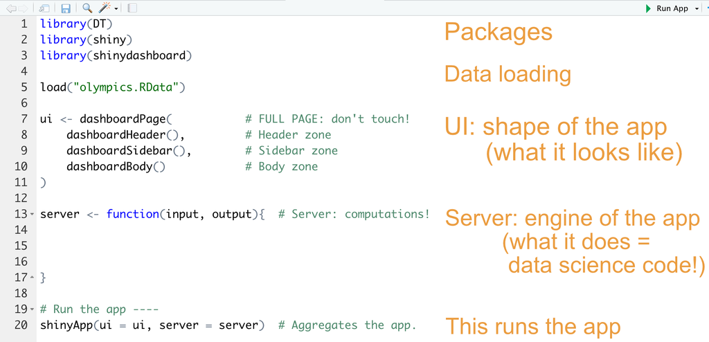

## Dashboard: simple structure (UI)

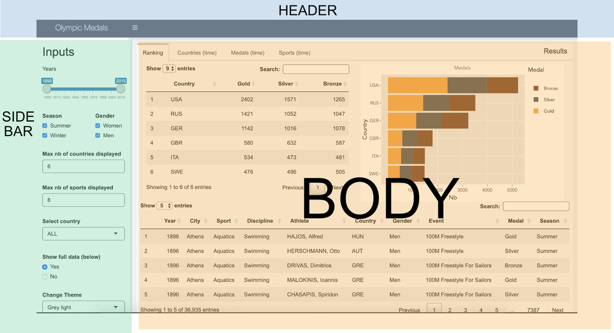

## The flow

Just like before (teaching = repeating!):

1. **inputs** (input$blabla) are defined by the control widgets in the sidebar (**UI**)
2. given these inputs, the server reactively creates the output in proper format (**Server**)
3. the **output** (output$blabla) is displayed in the body of the dashboard (back to **UI**)

The flow is

UI (sidebar) \(\rightarrow\) Server \(\rightarrow\) UI (body)

In the code, steps 1 & 3 will be aggregated in the UI section with a strong differentiation (**sidebar** versus **body**).

## Input: control widgets

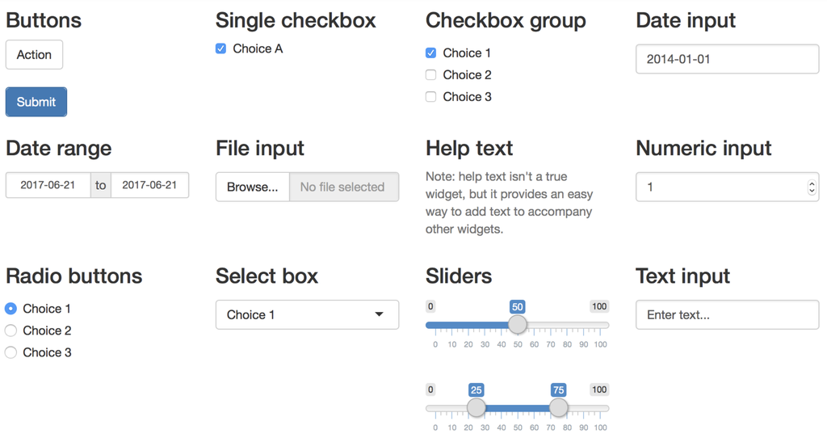

**source**: https://shiny.rstudio.com/tutorial/written-tutorial/lesson3/  
**source**: https://shiny.rstudio.com/gallery/widget-gallery.html  
**source**: https://mastering-shiny.org/basic-ui.html#inputs

## Widget syntax

```r
sliderInput(
  inputId = "id",               # For the server
  label = "What the user sees", # For the UI
  min = 0,
  max = 100,
  value = 50,                   # Default value
  step = 5)
```

In short:

```r
sliderInput("bla", h3("BlaBla"), # For the UI
  min = 0, max = 100,
  value = 50, step = 5)
```

## Output: dedicated functions

For each output type, there is a particular function:

| Content | UI (displaying) | Server (rendering = “creating”) |
| --- | --- | --- |
| simple numbers | valueBoxOutput() or infoBoxOutput() | renderValueBox() of renderInfoBox() |
| tables (DT package) | dataTableOutput() | renderDataTable() |
| simple plots | plotOutput() | renderPlot() |
| enhanced plots | plotlyOutput() | renderPlotly() |
| text | textOutput() | renderText() |

**source**: https://mastering-shiny.org/basic-ui.html#outputs

## Dialog between UI and Server

- UI and Server communicate via two variables: **input** & **output**.
- in the sidebar, each widget will be associated to a name, e.g., “year” or “gender” or “continent”, etc.
- in the server, the corresponding values will be **input**$year or **input**$gender or **input**$continent and can be used in the computation;
- in return, the server will build output objects, like **output**$table1 or **output**$plot2 which will then be displayed in the body of the UI
- then, in the UI Body: dataTableOutput(“table1), plotOutput(”plot2”).

In short, this gives (I repeat!): \[\text{UI sidebar} \overset{input}{\rightarrow} \text{Server} \overset{output}{\rightarrow} \text{UI body}\]

**Paraphrased**:  
UI sidebar (input), Server (input transformed in output), UI body (output).

## input & output: illustration

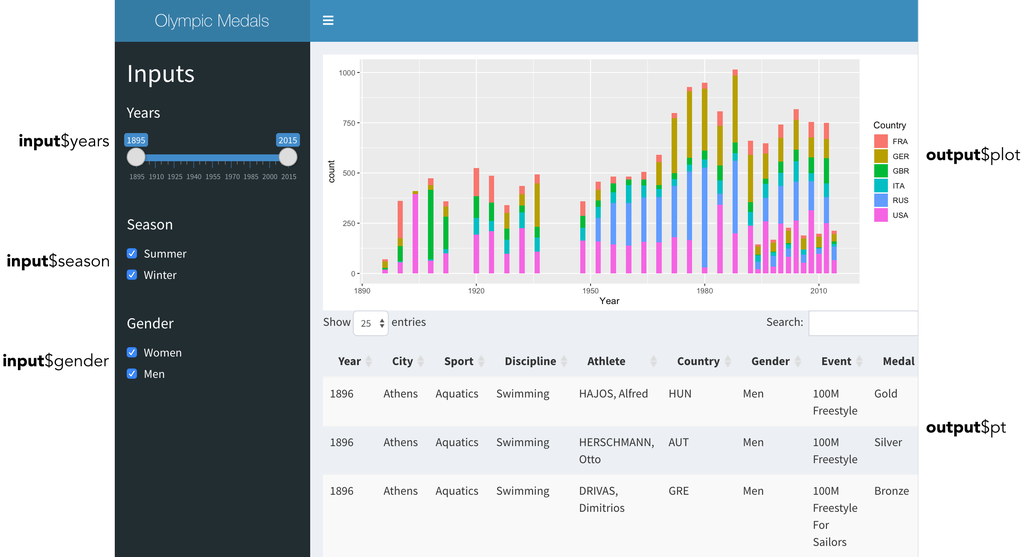

## Reactivity ( = why the app is interactive)

When the user changes some parameters in the UI (sidebar in a shinydashboard), this impacts what happens in the server.

In practice, it is better to resort to reactivity at an early stage in the structure, i.e., on the **data source**:

```r
data <- reactive({                  # Creates the dynamic data
  olympics <- olympics %>%          # Filter years, seasons & gender
    filter(Year >= input$years[1],
           Year <= input$years[2])
  return(olympics)
})
```

This is done via the **reactive**() function. \(\rightarrow\) only used in the server section.  
Reactive objects are functions. **BEWARE**: the syntaxes are not always obvious.

**source**: https://mastering-shiny.org/basic-reactivity.html

## input & output: on the server side

With a direct call and no return() in the reactive part.

```r
server <- function(input, output){
    data <- reactive({                       # Creates the dynamic data
        olympics %>%             # Filter years, seasons & gender
            filter(Year >= input$years[1],
                   Year <= input$years[2],
                   Season %in% input$season)
    })
    output$pt <- renderDataTable(data())     # Create the output object!
}
```

## Conditional expressions: if()

They are super useful for dynamic (**reactive**) filters!!! The structure is simple:

if(**condition**){  
**instruction** 1 (expression)  
**instruction** 2 (expression)  
**instruction** 3 (expression) ….

}

## Font sizes

**h1**(“text”) is for very large text.  
…  
**h6**(“other text”) is for very small text.

SIMPLE (that’s one short slide)!

## Golden (coding) rules

In the **UI** section:

- in a widget, the first argument is always the name of the **input**: **sliderInput**(“years”, h4(“Years”), …): the first one is the name (or id) of the variable created in R, the second one is the text that is displayed in the widget; It is the name that you then use in the server.  
- all elements are separated by a **comma**; this is true at **all levels**. **BUT**, there is no comma after the last element in a group or the last argument in a function.

In the **server** section:

- each element is expected to **return** an object. To return: use return() or a final call (like a ggplot or a pivot table).  
- elements to be updated must be wrapped inside a **reactive**() object on the server side (data variables mostly). They are functions!

## About the olympics dataset

```r
head(olympics)
```

| Year | City | Sport | Discipline | Athlete | Country | Gender | Event | Medal | Season |
| --- | --- | --- | --- | --- | --- | --- | --- | --- | --- |
| 1896 | Athens | Aquatics | Swimming | HAJOS, Alfred | HUN | Men | 100M Freestyle | Gold | Summer |
| 1896 | Athens | Aquatics | Swimming | HERSCHMANN, Otto | AUT | Men | 100M Freestyle | Silver | Summer |
| 1896 | Athens | Aquatics | Swimming | DRIVAS, Dimitrios | GRE | Men | 100M Freestyle For Sailors | Bronze | Summer |
| 1896 | Athens | Aquatics | Swimming | MALOKINIS, Ioannis | GRE | Men | 100M Freestyle For Sailors | Gold | Summer |
| 1896 | Athens | Aquatics | Swimming | CHASAPIS, Spiridon | GRE | Men | 100M Freestyle For Sailors | Silver | Summer |
| 1896 | Athens | Aquatics | Swimming | CHOROPHAS, Efstathios | GRE | Men | 1200M Freestyle | Bronze | Summer |

## Before you start coding your app

## Data preparation: find your database (if you haven’t yet!)

- Google dataset: https://toolbox.google.com/datasetsearch
- US Gov: https://www.data.gov
- FR Gov: https://www.data.gouv.fr/fr/
- Paris: https://opendata.paris.fr/
- Lyon: https://data.grandlyon.com
- Banque de France (financial time series): http://webstat.banque-france.fr/en/home.do
- 538 #1 (sports, politics & misc.): https://data.fivethirtyeight.com
- 538 #2 (sports, politics & misc.): https://github.com/fivethirtyeight/data
- Data World (miscellaneous): https://data.world
- Kaggle (miscellaneous): https://www.kaggle.com/datasets
- Iain Pardoe (miscellaneous): https://www.iainpardoe.com/teaching/dsc433/data.htm
- UC Irvine (miscellaneous) : http://archive.ics.uci.edu/ml/datasets.html
- rs.io (miscellaneous): http://rs.io/100-interesting-data-sets-for-statistics/

## REMINDER: Data preparation: convert & clean

- Usually, the data will come from excel-like files (xls, xlsx, csv).
- These files do not encode variables precisely.
- You need to make sure they have the right type and you can change it via the as.type functions: **as.numeric**(), **as.character**(), **as.factor**(), **as.Date**().
- For categorical variables (factors), you can encode the levels and specify if they are ordered or not, but you must then use the simple **factor**() function:

```r
factor(c("small", "large", "medium", "small"), levels = c("small", "medium", "large"), ordered = TRUE)
```

```
## [1] small  large  medium small
## Levels: small < medium < large
```

- to clean (abruptly) your dataset, you can use **na.omit**() function which removes the instances with missing values.

## REMINDER: Data preparation, saving

Easy: use the **save**() function. Keep the original RData format, it’s very convenient and well compressed.

```r
test <- sqrt(1:9)
save(test, file = "test.RData")
```

You can then access the data via **load**():

```r
load("test.RData")
```

Just make sure you are in the **right directory**!

## Takeaways

Two sides:

- the **UI** (shown) with a **sidebar** (where the user “plays” with inputs) and a **body** where the output is displayed.  
- the **server** (hidden) where the users choices are impacted on the output.  
- the **inputs** are defined in the UI and used by the server.  
- the server creates (or updates) the **outputs** that are displayed in the UI.

Chronologically, the way the app processes the flow:

1. in the **UI**, you create widgets (sliders, buttons, etc.) in the sidebar;  
2. the user changes the corresponding values/parameters;  
3. this is taken into account in the server via a **reactive()** structure;  
4. the server renders/creates objects (**renderPlot**(), **renderText**(), **renderDataTable**(), etc.);  
5. these objects are then retrived by the body of the UI and shown via **plotOutput**(), **textOutput**() and **dataTableOutput**().

## What are your questions?

A ‘bad’ question is better than no question (there are no bad questions).

**Tip**: for your project, choose a dataset with a mixture of numerical and categorical data. It is the best combination to create a nice looking dashboard!